# Week5: Homework

第15組(組員:賴怡廷、林孟慧、盧穎、陳鳯婷、郝逸清、林德昌)

# 作業二 (20pt) 自己的問卷自己分析

### (團體作業)

- 自製問卷 (typeform 或 google doc) 與內容，存成 csv 檔。
- 讀入 R，用你們學到的東西進行 (各種) 探索與分析。
- 問卷網址
- https://docs.google.com/forms/d/1KcfrzGobhQTI3zPISwlQPLtI1bjdUGyRkws0L0f4ehU/viewform?edit_requested=true#responses

```r
hw<-read.csv("/Users/luffy02468/dsR/data/hw.csv")
names(hw) <- c("Gender","Restaurant","Meals.Type","Waiting.Time","Living.Expense","old","Height","Weight")
hw
```

| Gender | Restaurant | Meals.Type | Waiting.Time | Living.Expense | old | Height | Weight |
| --- | --- | --- | --- | --- | --- | --- | --- |
| 女 | 大一女 | 麵類 | 8.0 | 6000 | 大四 | 158.0 | 56 |
| 男 | 大一女 | 飯類 | 10.0 | 6000 | 大四 | 174.0 | 72 |
| 女 | 小福 | 早餐類 | 10.0 | 6000 | 大四 | 155.0 | 60 |
| 男 | 大一女 | 飯類 | 10.0 | 8000 | 碩班 | 180.0 | 72 |
| 男 | 小福 | 早餐類 | 10.0 | 8000 | 碩班 | 168.0 | 56 |
| 女 | 大一女 | 飯類 | 10.0 | 10000 | 碩班 | 158.0 | 45 |
| 男 | 小福 | 麵類 | 15.0 | 10000 | 大四 | 176.0 | 65 |
| 男 | 小福 | 麵類 | 10.0 | 3000 | 大四 | 173.0 | 47 |
| 男 | 大一女 | 飯類 | 3.0 | 8000 | 大四 | 182.0 | 77 |
| 女 | 小福 | 飯類 | 12.0 | 8000 | 大四 | 160.0 | 50 |

[output cut: 41 more lines]

```r
library(dplyr)
library(ggplot2)
#'各餐廳平均等待時間
(a <- group_by(hw,Restaurant)%>%summarise(waiting.timeave=mean(Waiting.Time)))
```

| Restaurant | waiting.timeave |
| --- | --- |
| 大一女 | 8.666667 |
| 國青 | 2.000000 |
| 活大 | 26.400000 |
| 女九 | 12.571429 |
| 小福 | 8.733333 |
| 小小福 | 3.000000 |

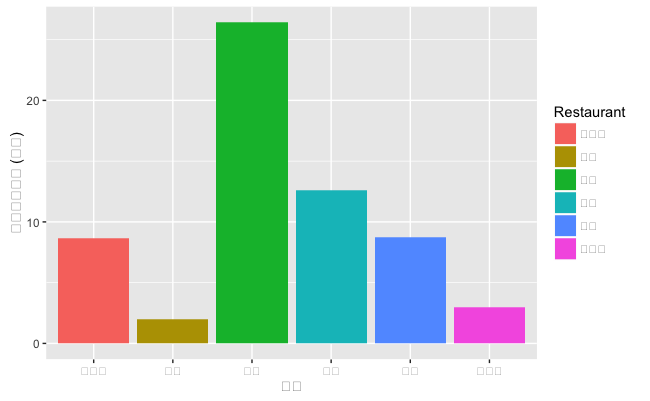

```r
df_a <- data.frame(Restaurant = a$Restaurant, waiting.timeave = a$waiting.timeave)
ggplot(df_a, aes(x=Restaurant,y=waiting.timeave,fill=Restaurant)) + geom_bar(stat = 'identity') +
  labs(y = "平均等待時間 (分鐘)") + labs(x = "餐廳")
```

```r
#'各餐廳平均每人BMI
(b <- group_by(hw,Restaurant)%>%summarise(BMIave=mean(Weight/(Height/100)^2)))
```

| Restaurant | BMIave |
| --- | --- |
| 大一女 | 21.32604 |
| 國青 | 20.32225 |
| 活大 | 200018.75710 |
| 女九 | 22.51547 |
| 小福 | 21.04375 |
| 小小福 | 22.46114 |

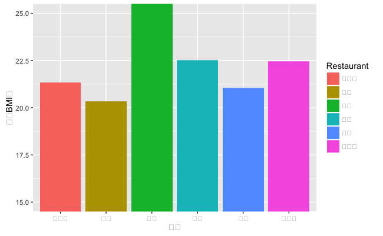

```r
df_b <- data.frame(Restaurant = b$Restaurant, BMIave = b$BMIave)
ggplot(df_b, aes(x=Restaurant,y=BMIave,fill=Restaurant)) + geom_bar(stat = 'identity') +
       labs(y = "平均BMI值") + labs(x = "餐廳") + coord_cartesian(ylim = c(15, 25))
```

```r
#'BMI值與餐點種類的關係
(c <- group_by(hw,Meals.Type)%>%summarise(BMIave=mean(Weight/(Height/100)^2)))
```

| Meals.Type | BMIave |
| --- | --- |
| 點心類 | 250017.45509 |
| 飯類 | 21.47192 |
| 麵類 | 20.85615 |
| 早餐類 | 22.76130 |

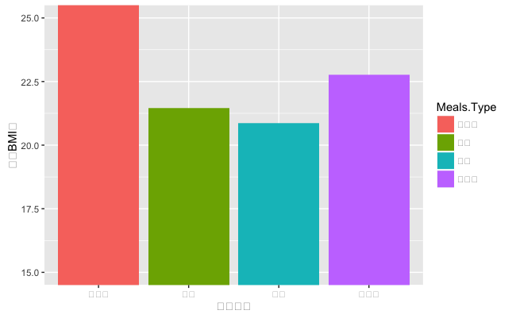

```r
df_c <- data.frame(Meals.Type = c$Meals.Type, BMIave = c$BMIave)
ggplot(df_c, aes(x=Meals.Type,y=BMIave,fill=Meals.Type)) + geom_bar(stat = 'identity') +
       labs(y = "平均BMI值") + labs(x = "餐點種類") + coord_cartesian(ylim = c(15, 25))
```

```r
#'各餐廳喜歡的餐點種類統計
table(hw$Restaurant,hw$Meals.Type)
```

```
         點心類 飯類 麵類 早餐類
  大一女      0   14    4      0
  國青        0    1    0      0
  活大        2    2    1      0
  女九        0    5    0      2
  小福        2    4    5      4
  小小福      0    2    0      0
```

由此表可知，最喜歡吃大一女的飯的人佔了大多數，喜歡吃大一女飯的人明顯比起其他餐廳的人來得多，我個人是覺得大一女的自助餐真的很好吃！ 另外喜歡國青和小小福的人明顯較少;喜愛飯類的比麵類的來得多。

```r
#'男女生活費金額比較
group_by(hw,Gender)%>%summarise(living.expense=mean(Living.Expense))
```

```
argument is not numeric or logical: returning NAargument is not numeric or logical: returning NA
```

| Gender | living.expense |
| --- | --- |
| 男 | NA |
| 女 | NA |

```r
#'男女生平均身高
group_by(hw,Gender)%>%summarise(height=mean(Height))
```

| Gender | height |
| --- | --- |
| 男 | 168.5037 |
| 女 | 158.7143 |

```r
#'男女生平均體重
group_by(hw,Gender)%>%summarise(weight=mean(Weight))
```

| Gender | weight |
| --- | --- |
| 男 | 435.07407 |
| 女 | 53.19048 |

```r
# 不同年級的平均等待時間
tapply(hw$Waiting.Time,hw$Grade,mean)
```

[output not shown]

大一大二喜歡不需要等太久的食物，而大三大四碩班生為了喜愛的食物相對願意等比較久，可能原因之一為大一大二課比較多，沒有時間去吃需要等太久的食物。

# Datacamp :

- [Intermediate-R](https://www.datacamp.com/courses/intermediate-r)
- [Writing functions](https://www.datacamp.com/courses/writing-functions-in-r)